# DNA Block - Problem Set 19

Author

Published

November 1, 2026

## Problem Set

Total points: 20.

## Load libraries

Load the data from the MNase-seq experiment.

```r
mnase_tbl <- read_bed(___)
```

In class we learned that MNase digestion yields nucleosomal “footprints” of ~150 bp in size. I’ve added blue vertical lines to emphasize positions of the major peak (intact nucleosomes) as well as smaller “sub-nucleosomal” peak.

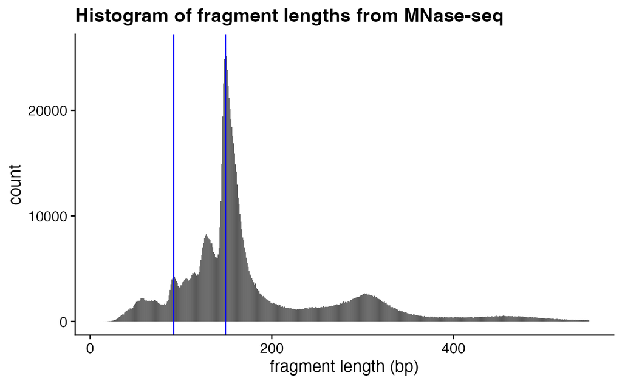

We can calculate the counts for the histogram above and more precisely determine the maximum signal using `which.max()` to identify the *index* of the maximum value in a vector (*not* the value itself!):

```r
frag_hist <-
  mnase_tbl |>
  mutate(frag_len = ___) |>
  count(frag_len)

# `which.max` takes a vector and gives us the index of the maximum value
max_idx <- which.max(___)

# now we can use that index to find the most abundant fragment size
ncp_max <- frag_hist$frag_len[max_idx]
```

## Question 1

Let’s take a closer look at the some of the smaller fragments in the MNase experiment. In particular, let’s zoom in on the populations of fragments that are smaller than 1 nucleosome in size, the peak between 85 and 95 bp (the left-most blue vertical line).

1. Use the above strategy to precisely determine the peak of this smaller size range. How big are those fragments? These are called “sub-nucleosomal” fragments.

```r
frag_hist_sub <- filter(
  frag_hist,
  ___
)

n_max_sub <- which.max(___)
# use the strategy above to identify the position of maximum signal
subnuc_max <- ___
```

**Answer:**

2. Do this one more time, and identify the position of maximum signal in the disome peak (i.e., the fragments protected by two nucleosomes).

```r
frag_hist_di <- filter(
  frag_hist,
  ___
)

n_max_di <- which.max(___)
dinuc_max <- ___
```

3. Recreate the histogram using ggplot2 (using relevant code from class 17) and add the blue vertical lines at the peak positions you calculated, including the position of the disomes above.

```r
ggplot(
  mnase_tbl,
  aes(x = ___)
) +
  geom_histogram(
    # single base-pair resolution
    binwidth = ___
  ) +
  labs(
    x = "___",
    title = "___"
  ) +
  theme_cowplot() +
  geom_vline(
    xintercept = ___,
    color = "blue"
  )
```

## Question 2 – 13 points

Next we’re going to look at *where* these sub-sucleosomes are with respect to intact nucleosomes.

Our strategy will be to compare the density of sub-nucleosomes relative to the mid-points of previously mapped nucleosomes. Specifically, our reference point will be the midpoints of the +1 nucleosomes.

So you’ll make a metaplot, but instead of using transcription start sites as the reference point, we’ll use the midpoints of the +1 nucleosome, and instead of MNase-seq signal density, you’ll count up the number of individual reads that intersect with windows around those midpoints.

1. First, load the relevant data. We’ll re-use the `yeast_mnase_chrII.bed.gz` data you loaded above, plus you’ll need to load two other files:
   - a “genome” file, `sacCer3.chrom.sizes`
   - a BED file, `yeast_p1_chrII.bed.gz` which contains the mid-points of the +1 nucleosomes on chromosome 2. Recall that the +1 nucleosome is the nucleosome downstream of the transcription start site.

```r
genome <- read_genome(___)

p1_tbl <- read_bed(___)
```

2. Next, we need the mid-points of nucleosomes for comparison. The following function needs fixing.

```r
calc_mids <- function(tbl, min_len, max_len) {
  tbl |>
    mutate(
      frag_len = ___
    ) |>
    filter(
      ___
    ) |>
    mutate(
      midpoint = ___
    ) |>
    select(chrom, midpoint) |>
    rename(start = midpoint) |>
    mutate(end = start + 1)
}
```

3. Now use this function to calculate the midpoints of the intact nucleosome fragments (around 149 bp) and the sub-nucleosomal fragments (around 90 bp). Expand these midpoints by 20 bp on either side using `bed_slop()`, since we’ll be looking for intersections with these intervals.

```r
ncp_mids_tbl <-
  # specify the min and the max sizes, expanding out from the max size 3 bp in each direction to capture the peak
  calc_mids(mnase_tbl, ___, ___) |>
  # now expand out by 20 bp on either side
  bed_slop(___, ___)

subnuc_mids_tbl <-
  calc_mids(mnase_tbl, ___, ___) |>
  bed_slop(___, ___)
```

4. Next, we need to make the intervals for the metaplot. We’ll look 100 bp up- and downstream of the +1 nucleosome positions, and make windows that are **1 bp** in size.

```r
p1_win_tbl <-
  bed_slop(
    p1_tbl,
    ___,
    ___
  ) |>
  bed_makewindows(
    ___
  )
```

5. Almost there! Now you just need to identify the number of short and long nuclesome fragments (based on their midpoints) that intersect with the +1 nucleosomes you defined above.

   Use `bed_intersect()` to identify fragments that overlap, and then just count the number of fragments per `.win_id` (don’t forget the .`.x` suffix). Note you will do this separately for the short and long fragments.

```r
ncp_mids_summary_tbl <-
  bed_intersect(
    p1_win_tbl,
    ncp_mids_tbl
  ) |>
  count(.win_id.x) |>
  mutate(type = "Intact nucleosomes (~149 bp)")

subnuc_mids_summary_tbl <-
  bed_intersect(
    p1_win_tbl,
    subnuc_mids_tbl
  ) |>
  count(.win_id.x) |>
  mutate(type = "Sub-nucleosomes (~90 bp)")
```

6. The following joins the tables you made together, and makes the x-axis more informative, by converting to position rather than window ID.

```r
win_ids <- seq(-100, 100, 1)

all_tbl <- bind_rows(
  ncp_mids_summary_tbl,
  subnuc_mids_summary_tbl
) |>
  mutate(win_ids = win_ids, .by = "type")
```

7. Finally, we plot the data with position on the x-axis, and count on the y-axis.

```r
ggplot(
  all_tbl,
  aes(x = win_ids, y = n)
) +
  # add a line representing nucleosome density
  geom_line(
    linewidth = 1,
    color = "red"
  ) +
  # facet by type of fragment
  facet_wrap(
    ~type,
    scales = "free_y"
  ) +
  theme_minimal_grid() +
  labs(
    x = "Position relative to +1 nucleosome midpoints",
    y = "Number of intersecting fragments",
    title = "Fragment density around +1 nucleosome midpoints"
  )
```

Your plot should look like this:

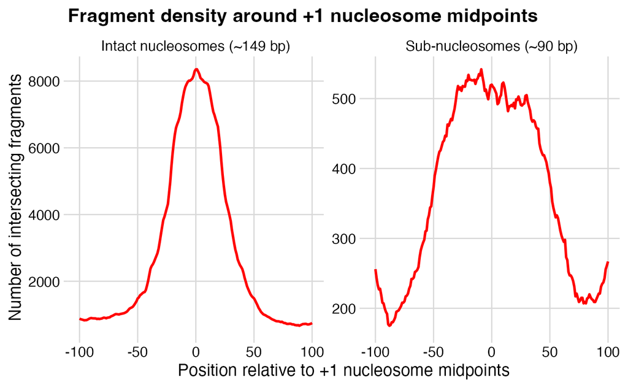

## Interpretation

How do you interpret these plots?

Rationalize the pattern for intact nucleosomes. What pattern did you expect to see?

**Answer:**

Rationalize the pattern for sub-nucleosome. How would you describe the positions of sub-nucleosomal fragments, relative to the +1 nucleosome midpoints? What might this mean with respect to gene transcription?

**Answer:**

What do the differences between signal magnitudes (reflected by the y-axis) mean?

**Answer:**

## Submit

Be sure to click the “Render” button to render the HTML output. Then paste the URL of this Posit Cloud project into the problem set on Canvas.